## v.1 March 19, 2019

# Imports

```python
import pandas as pd
import numpy as np
import os
import random
import scipy as sp
from sklearn.metrics import confusion_matrix
from sklearn.model_selection import train_test_split
from sklearn.preprocessing import normalize


# To plot pretty figures
%matplotlib inline
import matplotlib
import matplotlib.pyplot as plt
```

# notes:

### Load flights data.

Chose specific columns:

YEAR - dropped because this dataset is all from 2015

*MONTH - kept, 1-12

DAY - removed because unnecessary for generalization and too much to convert to dummies

*DAY_OF_WEEK - kept Mon = 1 -> Sunday = 7

*AIRLINE - kept, 14 different airlines

FLIGHT_NUMBER - removed, too specific

TAIL_NUMBER - "

*ORIGIN_AIRPORT - kept

*DESTINATION_AIRPORT - kept

*SCHEDULED_DEPARTURE - kept for time of day

DEPARTURE_TIME - removed, in delay = wheels off + taxi out

*DEPARTURE_DELAY - kept

TAXI_OUT - removed, folded into delay times

WHEELS_OFF- removed, folded into delay times

SCHEDULED_TIME - removed in delay

ELAPSED_TIME - removed, in delay = AIR_TIME + TAXI_IN + TAXI_OUT

AIR_TIME - removed

DISTANCE - removed, all domestic flights v.2 - added back in

WHEELS_ON - removed, in delay

TAXI_IN - removed, in delay

SCHEDULED_ARRIVAL - removed

ARRIVAL_TIME - removed = wheels on + taxi in

*ARRIVAL_DELAY - kept = ARRIVAL_TIME - SCHEDULED_ARRIVAL

*DIVERTED - kept

*CANCELLED - kept

CANCELLATION_REASON - removed

AIR_SYSTEM_DELAY,SECURITY_DELAY,AIRLINE_DELAY,LATE_AIRCRAFT_DELAY,WEATHER_DELAY - removed, not interested in delay type rn

Airline Delay could be interesting to look into later - because thats the only kind of delay that airlines are required to give compensation for.

# I imported 20% of the data and then fixed those airport codes. I didn't want to have to run the fixing code every single time, so it's marked down here

## ------ fixing begins -------

n = 5819078 skip = random.sample(range(1,n),(n-1163816)) flights = pd.read_csv('flights.csv',skiprows=skip ,low_memory=False)

flights.dtypes

len(flights)

would really have loved to fix all 5.8 million. Future work using spark + clusters. Also this is just for one year, so would be equally great to use more years

one thing I've noticed is that the data fixing slows down as it approaches the length of the array. I don't know what that could mean.

### fixing airport data

Some of the airports were listed using 5 digit numbers instead of 3 letter code. I used code by Scott Cole as a template for this section (see the link below). First fornatted all the codes, then make sure that they are strings. For all the codes that aren't 3 letters, look up their corresponding 5 digit code and replace. https://www.kaggle.com/srcole/fix-inconsistent-airport-codes

aircode1 = pd.read_csv('AirportCodes.csv', encoding='latin-1') aircode2 = pd.read_csv('FiveDigitAirportID.csv', encoding='latin-1')

aircode1 = aircode1.reset_index() aircode2 = aircode2.reset_index() aircodes = pd.merge(aircode1,aircode2,on='Description') aircode_dict = dict(zip(aircodes['ID'].astype(str),aircodes['Code']))

flights['ORIGIN_AIRPORT'] = flights['ORIGIN_AIRPORT'].values.astype(str) flights['DESTINATION_AIRPORT'] = flights['DESTINATION_AIRPORT'].values.astype(str)

for i in range(len(flights)): print(i) if len(flights['ORIGIN_AIRPORT'][i]) != 3: to_replace = flights['ORIGIN_AIRPORT'][i] value = aircode_dict[flights['ORIGIN_AIRPORT'][i]] flights = flights.replace(to_replace, value)

```
if len(flights['DESTINATION_AIRPORT'][i]) != 3:
    to_replace = flights['DESTINATION_AIRPORT'][i]
    value = aircode_dict[flights['DESTINATION_AIRPORT'][i]]
    flights = flights.replace(to_replace, value)
```

Save fixed flights to csv and load in again because I don't want to keep running the fixing loops. They take forever.

flights.to_csv(r'flights_fixedairports.csv', index=None, header = True)

## ------ fixing ends -------

# load fixed airport data

```python
flights = pd.read_csv('flights_fixedairports.csv',usecols = ['MONTH','DAY_OF_WEEK','AIRLINE','ORIGIN_AIRPORT','DESTINATION_AIRPORT','SCHEDULED_DEPARTURE', 'DEPARTURE_DELAY','ARRIVAL_DELAY','DIVERTED', 'CANCELLED', 'DISTANCE'],low_memory=False)
flights = flights.sample(frac=1).reset_index(drop=True)  # randomize rows so that data is not chronologically sorted
```

## visualzing the scope of the delay

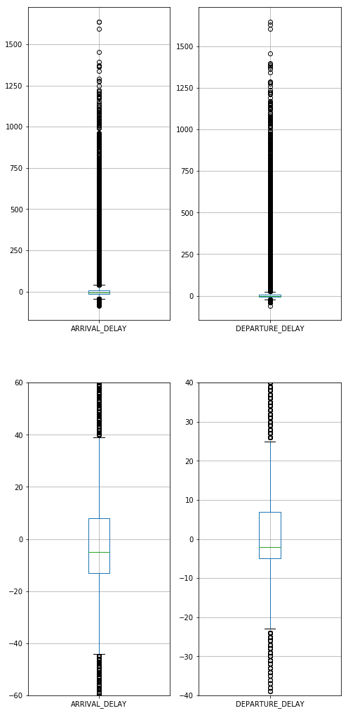

```python
fig = plt.figure(figsize=(8, 18))
x1, x2, y1, y2, y3, y4 = -1, 1, -40, 40, -60, 60 # specify the limits


sub1 = fig.add_subplot(221)
flights.boxplot(column = ['ARRIVAL_DELAY'])

sub2 = fig.add_subplot(222)
flights.boxplot(column = ['DEPARTURE_DELAY'])

sub3 = fig.add_subplot(223)
sub3.margins(x=0, y=-0.05)
sub3.set_xlim(x1, x2) # apply the x-limits
sub3.set_ylim(y3, y4) # apply the y-limits
flights.boxplot(column = ['ARRIVAL_DELAY'])


sub4 = fig.add_subplot(224)
sub4.margins(x=0, y=-0.005)
sub4.set_xlim(x1, x2) # apply the x-limits
sub4.set_ylim(y1, y2) # apply the y-limits
flights.boxplot(column = ['DEPARTURE_DELAY'])
plt.savefig('delay.png', bbox_inches='tight')
```

```python
# calculate quartiles
q1 = flights['ARRIVAL_DELAY'].quantile(.25)
q2 = flights['ARRIVAL_DELAY'].quantile(.5)
q3 = flights['ARRIVAL_DELAY'].quantile(.75)
# calculate min/max
data_min, data_max = flights['ARRIVAL_DELAY'].min(), flights['ARRIVAL_DELAY'].max()
# print 5-number summary
print('Min: %.3f, Q1: %.3f, Median: %.3f, Q3: %.3f, Max: %.3f' % (data_min, q1, q2, q3, data_max))
```

```
Min: -87.000, Q1: -13.000, Median: -5.000, Q3: 8.000, Max: 1638.000
```

```python
# calculate quartiles
q1 = flights['DEPARTURE_DELAY'].quantile(.25)
q2 = flights['DEPARTURE_DELAY'].quantile(.5)
q3 = flights['DEPARTURE_DELAY'].quantile(.75)
# calculate min/max
data_min, data_max = flights['DEPARTURE_DELAY'].min(), flights['DEPARTURE_DELAY'].max()
# print 5-number summary
print('Min: %.3f, Q1: %.3f, Median: %.3f, Q3: %.3f, Max: %.3f' % (data_min, q1, q2, q3, data_max))
```

```
Min: -61.000, Q1: -5.000, Median: -2.000, Q3: 7.000, Max: 1649.000
```

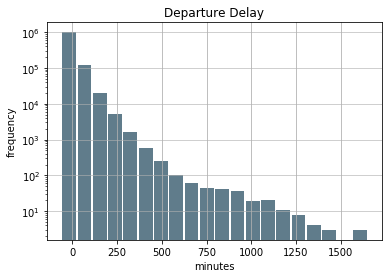

```python
flights['DEPARTURE_DELAY'].plot.hist(grid=True, bins=20, rwidth=0.9,
                   color='#607c8b', log = True)
plt.title('Departure Delay')
plt.xlabel('minutes')
plt.ylabel('frequency')
plt.grid(axis='y', alpha= 0.75)
plt.savefig('departure.png', bbox_inches='tight')
```

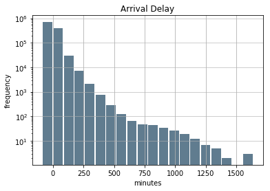

```python
flights['ARRIVAL_DELAY'].plot.hist(grid=True, bins=20, rwidth=0.9,
                   color='#607c8f', log = True)
plt.title('Arrival Delay')
plt.xlabel('minutes')
plt.ylabel('frequency')
plt.grid(axis='y', alpha= 0.75)
plt.savefig('arrival.png', bbox_inches='tight')
```

## Creating a column describing whether significant delay or got cancelled

FAA says a delay is > 15 minutes but DOT has not defined "significant delay", probabaly politics I chose greater than 1 hour because I feel that's when you are seriously inconvienced.

- negative delay values mean the plane arrived or departed earlier than the scheduled time.

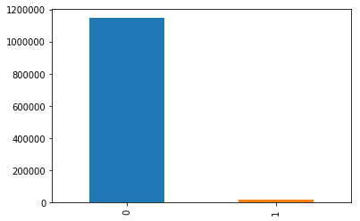

```python
flights['CANCELLED'].value_counts().plot(kind='bar')
```

```python
def late_or_cancelled(x):
    #if x['CANCELLED'] == 1 or x['total delay'] > 15:
    if x['CANCELLED'] == 1 or x['ARRIVAL_DELAY'] >= 60 or x['DEPARTURE_DELAY'] >= 60:
        return 1
    else:
        return 0

flights['late or cancelled'] = flights.apply(late_or_cancelled,axis = 1)
```

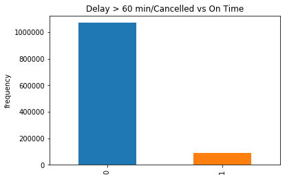

```python
flights['late or cancelled'].value_counts().plot(kind='bar')
plt.title('Delay > 60 min/Cancelled vs On Time')
plt.ylabel('frequency')
plt.savefig('Target.png', bbox_inches='tight')
```

```python
len(flights)
```

```
1163817
```

# Edit some catagorical features to make them better to work with

## Since departure time is a categorical feature, I will devide it into 4 different sections

I will devide it into 6 hour sections stating with midnight

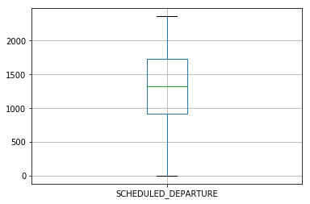

```python
boxplot = flights.boxplot(column=['SCHEDULED_DEPARTURE'])
```

```python
# calculate quartiles
q1 = flights['SCHEDULED_DEPARTURE'].quantile(.25)
q2 = flights['SCHEDULED_DEPARTURE'].quantile(.5)
q3 = flights['SCHEDULED_DEPARTURE'].quantile(.75)
# calculate min/max
data_min, data_max = flights['SCHEDULED_DEPARTURE'].min(), flights['SCHEDULED_DEPARTURE'].max()
# print 5-number summary
print('Min: %.3f, Q1: %.3f, Median: %.3f, Q3: %.3f, Max: %.3f' % (data_min, q1, q2, q3, data_max))
```

```
Min: 1.000, Q1: 917.000, Median: 1325.000, Q3: 1730.000, Max: 2359.000
```

```python
flights['SCHEDULED_DEPARTURE'] = np.ceil(flights['SCHEDULED_DEPARTURE']/600).apply(int)
```

## taking a look at unique airports

```python
len(flights['ORIGIN_AIRPORT'].value_counts())
```

```
323
```

```python
print(max(flights['DESTINATION_AIRPORT'].value_counts()), min(flights['DESTINATION_AIRPORT'].value_counts()))
```

```
76148 9
```

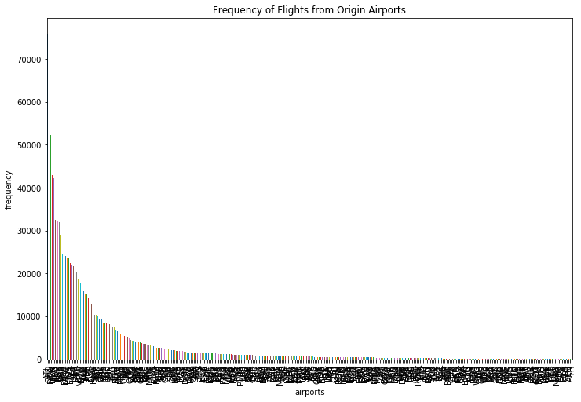

```python
plt.figure(figsize=(12, 8))
flights['ORIGIN_AIRPORT'].value_counts().plot(kind='bar')
plt.title('Frequency of Flights from Origin Airports')
plt.ylabel('frequency')
plt.xlabel('airports')
plt.savefig('origin_all.png', bbox_inches='tight')
```

```python
print(max(flights['ORIGIN_AIRPORT'].value_counts()), min(flights['ORIGIN_AIRPORT'].value_counts()))
```

```
75824 5
```

### used for getting rid of origin/ destination below a threshold

```python
v = flights['ORIGIN_AIRPORT']
c=(v.value_counts()).to_dict()
```

```python
max_origin = c[max(c.keys(), key=(lambda k: c[k]))]
```

```python
for key, value in c.items():
    if int(value) < (.05 * max_origin):
        flights = flights.drop(flights[flights['ORIGIN_AIRPORT'] == key].index)
        flights = flights.drop(flights[flights['DESTINATION_AIRPORT'] == key].index)
```

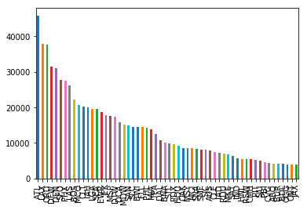

```python
flights['DESTINATION_AIRPORT'].value_counts().plot(kind='bar')
```

```python
y = flights['DESTINATION_AIRPORT']
d=(y.value_counts()).to_dict()
max_destination = d[max(d.keys(), key=(lambda k: d[k]))]
```

```python
for key, value in d.items():
    if int(value) < (.05 * max_destination):
        flights = flights.drop(flights[flights['ORIGIN_AIRPORT'] == key].index)
        flights = flights.drop(flights[flights['DESTINATION_AIRPORT'] == key].index)
```

```python
print(max(flights['ORIGIN_AIRPORT'].value_counts()), min(flights['ORIGIN_AIRPORT'].value_counts()))
```

```
45829 3868
```

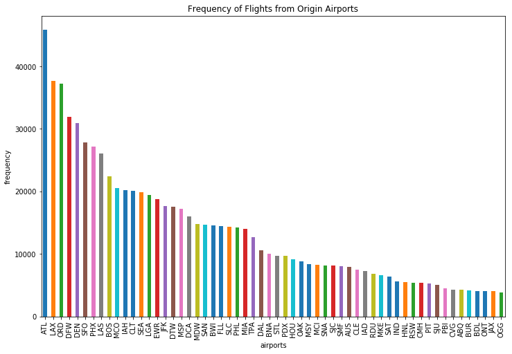

```python
plt.figure(figsize=(12, 8))
flights['ORIGIN_AIRPORT'].value_counts().plot(kind='bar')
plt.title('Frequency of Flights from Origin Airports')
plt.ylabel('frequency')
plt.xlabel('airports')
plt.savefig('origin.png', bbox_inches='tight')
```

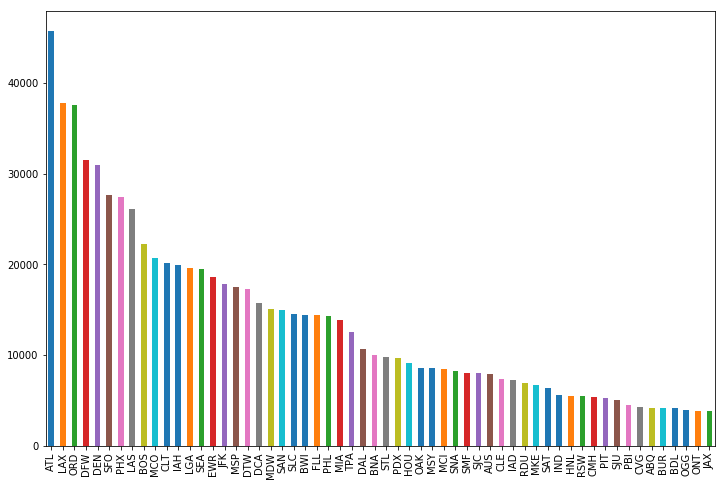

```python
plt.figure(figsize=(12, 8))
flights['DESTINATION_AIRPORT'].value_counts().plot(kind='bar')
plt.savefig('destination.png', bbox_inches='tight')
```

## Plotting being late or not vs different features

```python
Delay_vs_Day_of_Week = pd.DataFrame({'delays' : flights.groupby(['DAY_OF_WEEK'])['late or cancelled'].mean()}).reset_index()
Delay_vs_MONTH = pd.DataFrame({'delays' : flights.groupby(['MONTH'])['late or cancelled'].mean()}).reset_index()
Delay_vs_AIRLINE = pd.DataFrame({'delays' : flights.groupby(['AIRLINE'])['late or cancelled'].mean()})#.reset_index()
Delay_vs_SCHEDULED_DEPARTURE = pd.DataFrame({'delays' : flights.groupby(['SCHEDULED_DEPARTURE'])['late or cancelled'].mean()}).reset_index()

#Delay_vs_Day_of_Week.plot(x='DAY_OF_WEEK', y='delays')
#Delay_vs_Day_of_Week['delays'].hist(hold=None)
```

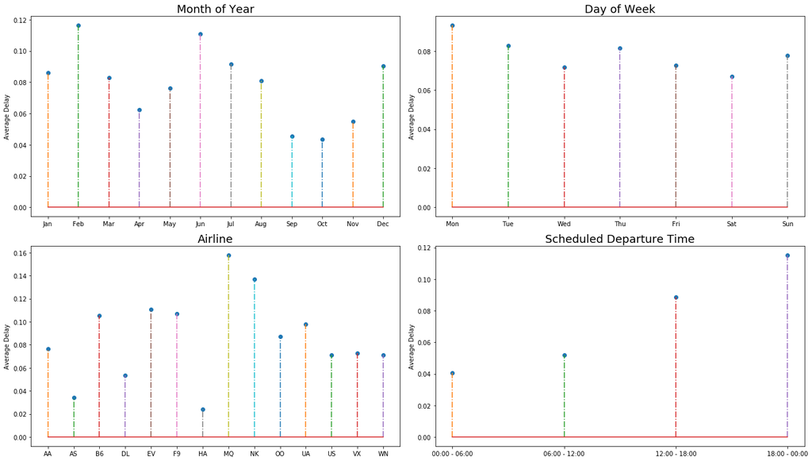

```python
fig = plt.figure(figsize=(18.5, 10.5))

sub1 = fig.add_subplot(221) # instead of plt.subplot(2, 2, 1)
sub1.set_title('Month of Year', fontsize=18)
sub1.stem(Delay_vs_MONTH['MONTH'], Delay_vs_MONTH['delays'], linefmt='-.', markerfmt='o')
sub1.set_xticks([1, 2, 3, 4, 5, 6, 7,8, 9, 10, 11, 12])
sub1.set_xticklabels(['Jan','Feb','Mar','Apr','May','Jun','Jul', 'Aug', 'Sep', 'Oct', 'Nov', 'Dec'])
sub1.set_ylabel('Average Delay')



sub2 = fig.add_subplot(222)
sub2.set_title('Day of Week', fontsize=18)
sub2.stem(Delay_vs_Day_of_Week['DAY_OF_WEEK'], Delay_vs_Day_of_Week['delays'], linefmt='-.', markerfmt='o')
sub2.set_xticks([1, 2, 3, 4, 5, 6, 7])
sub2.set_xticklabels(['Mon','Tue','Wed','Thu','Fri','Sat','Sun'])
sub2.set_ylabel('Average Delay')

sub3 = fig.add_subplot(223)
sub3.set_title('Airline', fontsize=18)
sub3.stem(range(len(Delay_vs_AIRLINE)), Delay_vs_AIRLINE['delays'], linefmt='-.', markerfmt='o')
sub3.set_xticks(range(len(Delay_vs_AIRLINE)))
sub3.set_xticklabels(Delay_vs_AIRLINE.index)
sub3.set_ylabel('Average Delay')

sub4 = fig.add_subplot(224)
sub4.set_title('Scheduled Departure Time', fontsize=18)
sub4.set_xticks([0, 1, 2, 3])
sub4.set_xticklabels(['00:00 - 06:00','06:00 - 12:00','12:00 - 18:00','18:00 - 00:00'])
sub4.stem(range(len(Delay_vs_SCHEDULED_DEPARTURE)), Delay_vs_SCHEDULED_DEPARTURE['delays'], linefmt='-.', markerfmt='o')
sub4.set_ylabel('Average Delay')

plt.tight_layout()
plt.show()
fig.savefig('stats.png')
```

# attempted risk assesment of the airline carriers. Did not pan out how I wanted so markeddown for now.

delayed_by_carrier = flights.groupby(['AIRLINE','late or cancelled']).size().unstack().reset_index() delayed_by_carrier['flights_count'] = (delayed_by_carrier[False] + delayed_by_carrier[True]) delayed_by_carrier['proportion_delayed'] = delayed_by_carrier[True] / delayed_by_carrier['flights_count'] delayed_by_carrier.sort_values('proportion_delayed', ascending=False)

delayed_by_carrier['proportion_delayed'].plot(kind='bar')

del delayed_by_carrier['flights_count'] del delayed_by_carrier[1] del delayed_by_carrier[0]

delayed_by_carrier.head()

flights = flights.merge(delayed_by_carrier, on = 'AIRLINE', how = 'left')

flights.head()

flights['airline_risk'] = flights['proportion_delayed']

del flights['proportion_delayed'] del flights['AIRLINE']

# Make copy of flights dataframe to use with regression -- will need to keep the delays

```python
# make copy for regression
regress_flights = flights.copy(deep = True)
```

# Getting rid of unnecessary data for classification

```python
del flights['ARRIVAL_DELAY']
del flights['DEPARTURE_DELAY']
del flights['CANCELLED']
```

# Now save a slice for Validation later

##### classification

```python
train_flights, validate_flights = train_test_split(flights, test_size = 0.1, random_state=42)
```

##### for regression

```python
train_regress_flights, validate_regress_flights = train_test_split(regress_flights, test_size = 0.1, random_state=42)
```

## Correcting for target bias on training data

###### on classification data

```python
minorityN = len(train_flights[train_flights['late or cancelled'] == 1]) # get the total count of low-frequency group
minority_indices = train_flights[train_flights['late or cancelled'] == 1].index
minority_sample = train_flights.loc[minority_indices]

majority_indices = train_flights[train_flights['late or cancelled'] == 0].index
random_indices = np.random.choice(majority_indices, minorityN, replace=False) # use the low-frequency group count to randomly sample from high-frequency group
majority_sample = train_flights.loc[random_indices]

merged_sample = pd.concat([minority_sample, majority_sample], ignore_index=True) # merging all the low-frequency group sample and the new (randomly selected) high-frequency sample together
```

###### on regression data

```python
minorityN = len(train_regress_flights[train_regress_flights['late or cancelled'] == 1]) # get the total count of low-frequency group
minority_indices = train_regress_flights[train_regress_flights['late or cancelled'] == 1].index
minority_sample = train_regress_flights.loc[minority_indices]

majority_indices = train_regress_flights[train_regress_flights['late or cancelled'] == 0].index
random_indices = np.random.choice(majority_indices, minorityN, replace=False) # use the low-frequency group count to randomly sample from high-frequency group
majority_sample = train_regress_flights.loc[random_indices]

merged_regress_sample = pd.concat([minority_sample, majority_sample], ignore_index=True) # merging all the low-frequency group sample and the new (randomly selected) high-frequency sample together
```

### checking the data

```python
merged_sample.head()
```

|  | MONTH | DAY_OF_WEEK | AIRLINE | ORIGIN_AIRPORT | DESTINATION_AIRPORT | SCHEDULED_DEPARTURE | DISTANCE | DIVERTED | late or cancelled |
| --- | --- | --- | --- | --- | --- | --- | --- | --- | --- |
| 0 | 11 | 7 | EV | EWR | DCA | 2 | 199 | 0 | 1 |
| 1 | 4 | 1 | NK | MSP | LAS | 4 | 1299 | 0 | 1 |
| 2 | 7 | 2 | UA | LAX | ORD | 4 | 1744 | 0 | 1 |
| 3 | 8 | 4 | AA | SEA | PHL | 2 | 2378 | 0 | 1 |
| 4 | 4 | 2 | OO | SFO | PDX | 3 | 550 | 0 | 1 |

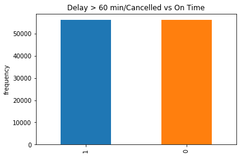

```python
merged_sample['late or cancelled'].value_counts().plot(kind='bar')
plt.title('Delay > 60 min/Cancelled vs On Time')
plt.ylabel('frequency')
plt.savefig('corrected.png', bbox_inches='tight')
```

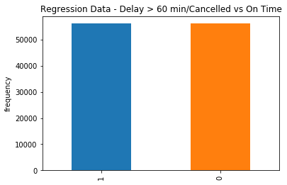

```python
merged_regress_sample['late or cancelled'].value_counts().plot(kind='bar')
plt.title('Regression Data - Delay > 60 min/Cancelled vs On Time')
plt.ylabel('frequency')
plt.savefig('corrected.png', bbox_inches='tight')
```

# Turn catagorical variables into dummy variables

#### classification regular + validate set

```python
Newflights_dummy = pd.get_dummies(merged_sample, columns = ['MONTH','AIRLINE','DAY_OF_WEEK', 'ORIGIN_AIRPORT', 'DESTINATION_AIRPORT', 'SCHEDULED_DEPARTURE'], drop_first = True)
```

```python
validate_flight_dummy = pd.get_dummies(validate_flights, columns = ['MONTH','AIRLINE','DAY_OF_WEEK', 'ORIGIN_AIRPORT', 'DESTINATION_AIRPORT', 'SCHEDULED_DEPARTURE'], drop_first = True)
```

#### regression regular + validate set

```python
New_regress_flights_dummy = pd.get_dummies(merged_regress_sample, columns = ['MONTH','AIRLINE', 'DAY_OF_WEEK', 'ORIGIN_AIRPORT', 'DESTINATION_AIRPORT', 'SCHEDULED_DEPARTURE'], drop_first = True)
```

```python
validate_regress_flight_dummy = pd.get_dummies(validate_regress_flights, columns = ['MONTH','AIRLINE','DAY_OF_WEEK', 'ORIGIN_AIRPORT', 'DESTINATION_AIRPORT', 'SCHEDULED_DEPARTURE'], drop_first = True)
```

## Insert target of late or cancelled into 0th position

```python
Newflights_dummy.insert(0, 'target', Newflights_dummy['late or cancelled'])
del Newflights_dummy['late or cancelled']
```

```python
validate_flight_dummy.insert(0, 'target', validate_flight_dummy['late or cancelled'])
del validate_flight_dummy['late or cancelled']
```

### checking collinearity of variables included in data

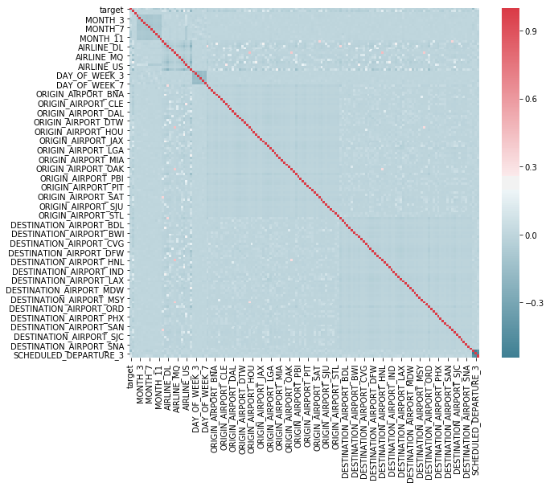

```python
import seaborn as sns

f, ax = plt.subplots(figsize=(10, 8))
corr = Newflights_dummy.corr()
sns.heatmap(corr, mask=np.zeros_like(corr, dtype=np.bool), cmap=sns.diverging_palette(220, 10, as_cmap=True),
            square=True, ax=ax)
```

```python
pd.DataFrame(np.linalg.inv(corr.values), index = corr.index, columns=corr.columns)
```

|  | target | DISTANCE | DIVERTED | MONTH_2 | MONTH_3 | MONTH_4 | MONTH_5 | MONTH_6 | MONTH_7 | MONTH_8 | ... | DESTINATION_AIRPORT_SJC | DESTINATION_AIRPORT_SJU | DESTINATION_AIRPORT_SLC | DESTINATION_AIRPORT_SMF | DESTINATION_AIRPORT_SNA | DESTINATION_AIRPORT_STL | DESTINATION_AIRPORT_TPA | SCHEDULED_DEPARTURE_2 | SCHEDULED_DEPARTURE_3 | SCHEDULED_DEPARTURE_4 |
| --- | --- | --- | --- | --- | --- | --- | --- | --- | --- | --- | --- | --- | --- | --- | --- | --- | --- | --- | --- | --- | --- |
| target | 1.108620 | 0.030091 | -0.017752 | -0.044531 | 0.009752 | 0.050571 | 0.024937 | -0.034142 | -0.006372 | 0.012324 | ... | 2.636280e-03 | -0.000249 | 0.012758 | -0.001686 | 0.018161 | 0.008490 | 0.002654 | -0.076783 | -2.281105e-01 | -0.269173 |
| DISTANCE | 0.030091 | 1.416650 | -0.030794 | 0.010596 | -0.001052 | 0.002564 | 0.002618 | -0.005657 | -0.000739 | 0.009680 | ... | 6.527237e-03 | -0.089234 | -0.041821 | 0.014924 | -0.004906 | -0.011076 | -0.010833 | -0.027713 | 1.002575e-02 | 0.025786 |
| DIVERTED | -0.017752 | -0.030794 | 1.004280 | -0.002140 | -0.001729 | -0.009137 | -0.013546 | -0.013347 | -0.005037 | -0.010748 | ... | -9.854640e-03 | -0.004334 | -0.002586 | -0.003589 | -0.015482 | -0.002394 | -0.010993 | -0.006183 | -5.171366e-03 | -0.004663 |
| MONTH_2 | -0.044531 | 0.010596 | -0.002140 | 1.894893 | 0.971583 | 0.900630 | 0.953672 | 1.040794 | 1.005010 | 0.974261 | ... | 4.962060e-03 | -0.001607 | 0.007027 | -0.003840 | 0.002618 | -0.004318 | 0.001046 | 0.017620 | 3.130244e-02 | 0.028301 |
| MONTH_3 | 0.009752 | -0.001052 | -0.001729 | 0.971583 | 1.880460 | 0.898501 | 0.949664 | 1.034036 | 1.001894 | 0.970405 | ... | -1.630587e-03 | -0.007569 | -0.008975 | 0.003910 | -0.006380 | -0.008861 | -0.006667 | 0.042423 | 3.510185e-02 | 0.008291 |
| MONTH_4 | 0.050571 | 0.002564 | -0.009137 | 0.900630 | 0.898501 | 1.768267 | 0.886742 | 0.962864 | 0.937273 | 0.905675 | ... | -3.070167e-03 | -0.007599 | -0.002976 | 0.000638 | -0.002434 | -0.004997 | -0.001420 | 0.031849 | 2.868029e-02 | -0.003200 |
| MONTH_5 | 0.024937 | 0.002618 | -0.013546 | 0.953672 | 0.949664 | 0.886742 | 1.857378 | 1.022405 | 0.990771 | 0.959628 | ... | 1.198405e-02 | 0.008773 | 0.013553 | 0.007481 | 0.012769 | 0.005391 | 0.009967 | 0.040898 | 2.698201e-02 | -0.002856 |
| MONTH_6 | -0.034142 | -0.005657 | -0.013347 | 1.040794 | 1.034036 | 0.962864 | 1.022405 | 2.019214 | 1.082420 | 1.046453 | ... | 2.259105e-03 | 0.000087 | 0.001620 | 0.001382 | 0.000420 | -0.005533 | 0.006513 | 0.059306 | 3.806937e-02 | -0.011901 |
| MONTH_7 | -0.006372 | -0.000739 | -0.005037 | 1.005010 | 1.001894 | 0.937273 | 0.990771 | 1.082420 | 1.980639 | 1.036761 | ... | 4.896873e-03 | -0.004068 | 0.006567 | 0.005970 | 0.001003 | 0.003589 | 0.006433 | 0.046043 | 2.727392e-02 | -0.013201 |
| MONTH_8 | 0.012324 | 0.009680 | -0.010748 | 0.974261 | 0.970405 | 0.905675 | 0.959628 | 1.046453 | 1.036761 | 1.918974 | ... | 4.372822e-04 | -0.010958 | -0.001185 | -0.001782 | -0.003757 | -0.002380 | 0.003098 | 0.047099 | 2.762818e-02 | -0.011212 |
| MONTH_9 | 0.084949 | 0.004232 | 0.001164 | 0.833419 | 0.834239 | 0.782801 | 0.825681 | 0.895955 | 0.893133 | 0.864464 | ... | -2.135577e-03 | 0.000023 | 0.002081 | -0.003883 | -0.001301 | 0.000929 | 0.005626 | -0.002101 | -1.801648e-02 | -0.025801 |
| MONTH_10 | 0.091507 | 0.009286 | -0.001148 | 0.842757 | 0.842965 | 0.792529 | 0.835239 | 0.902315 | 0.899625 | 0.872812 | ... | 7.612352e-03 | 0.006838 | 0.013422 | 0.005726 | 0.001544 | 0.010297 | 0.017533 | 0.008702 | 3.454981e-03 | -0.005485 |
| MONTH_11 | 0.068635 | 0.012575 | -0.004469 | 0.879954 | 0.878750 | 0.822491 | 0.870660 | 0.944125 | 0.936069 | 0.908709 | ... | 7.620896e-03 | 0.002434 | 0.005957 | 0.007317 | -0.005902 | 0.002851 | 0.009023 | 0.042884 | 2.963860e-02 | 0.012021 |
| MONTH_12 | -0.007882 | 0.001114 | -0.004381 | 0.973505 | 0.968992 | 0.903505 | 0.957876 | 1.045295 | 1.034712 | 1.000625 | ... | 7.315616e-03 | -0.005999 | -0.000985 | 0.006669 | -0.002732 | -0.002135 | -0.000143 | 0.044318 | 4.331682e-02 | 0.020955 |
| AIRLINE_AS | 0.033585 | 0.068511 | -0.004079 | -0.007115 | -0.005007 | 0.000264 | -0.001349 | -0.004012 | 0.034183 | 0.035328 | ... | -7.959812e-03 | 0.027794 | 0.002946 | 0.015275 | -0.014938 | 0.024510 | 0.027298 | -0.063211 | -4.744747e-02 | -0.043283 |
| AIRLINE_B6 | -0.016843 | 0.012112 | 0.001599 | 0.004227 | 0.001625 | 0.011975 | 0.013777 | 0.008955 | 0.051498 | 0.044979 | ... | 9.793470e-03 | -0.112190 | 0.004780 | 0.008434 | 0.024669 | 0.035296 | -0.021002 | 0.001747 | 9.192788e-03 | -0.056491 |
| AIRLINE_DL | 0.042875 | 0.050165 | 0.002891 | -0.032510 | -0.025607 | -0.018699 | -0.021313 | -0.025625 | 0.048758 | 0.049227 | ... | 2.319335e-02 | 0.037062 | -0.159084 | 0.013022 | 0.030423 | 0.038622 | 0.019187 | -0.062370 | -7.160641e-02 | -0.043269 |
| AIRLINE_EV | -0.030247 | 0.168391 | -0.002251 | 0.004366 | 0.010368 | 0.022413 | 0.023247 | 0.023804 | 0.072392 | 0.079585 | ... | 1.331853e-02 | 0.022969 | 0.009479 | 0.010576 | 0.025624 | -0.016133 | 0.053132 | -0.044132 | -3.720331e-02 | -0.035632 |
| AIRLINE_F9 | -0.035651 | 0.016498 | 0.001268 | -0.005355 | -0.003081 | -0.003451 | -0.009347 | -0.007777 | 0.020814 | 0.032937 | ... | -1.363272e-03 | 0.015984 | -0.020849 | -0.002695 | -0.005923 | -0.008243 | -0.009868 | 0.023224 | 1.662720e-02 | -0.010859 |
| AIRLINE_HA | 0.030100 | 0.250989 | -0.004242 | 0.000221 | -0.003268 | 0.002011 | 0.005687 | 0.001485 | 0.003363 | 0.010438 | ... | -1.575549e-02 | -0.006315 | -0.002967 | 0.002578 | 0.001548 | 0.006256 | 0.003502 | 0.006019 | 2.261895e-02 | 0.038361 |
| AIRLINE_MQ | -0.043299 | 0.158887 | 0.007294 | -0.000719 | 0.018100 | 0.025324 | 0.028854 | 0.029522 | 0.056450 | 0.051299 | ... | 3.174094e-02 | 0.036434 | 0.030027 | 0.029006 | 0.039167 | 0.007635 | 0.071349 | -0.003755 | -3.903162e-03 | 0.009048 |
| AIRLINE_NK | -0.061336 | -0.000077 | 0.003402 | 0.003182 | 0.001524 | -0.000551 | -0.026357 | -0.037863 | 0.023575 | 0.015616 | ... | 5.949250e-04 | 0.004739 | -0.007729 | -0.003480 | 0.007455 | 0.012274 | -0.033191 | 0.030578 | 4.637383e-02 | -0.012848 |
| AIRLINE_OO | -0.037348 | 0.256885 | -0.000743 | 0.009160 | 0.010549 | -0.003777 | 0.003211 | 0.006786 | 0.047345 | 0.055216 | ... | 3.093410e-02 | 0.071175 | -0.075264 | 0.015757 | 0.059949 | 0.076957 | 0.113155 | -0.054294 | -5.675640e-02 | -0.021990 |
| AIRLINE_UA | -0.029530 | -0.049801 | 0.002002 | -0.000639 | -0.007672 | -0.011482 | -0.019127 | -0.033138 | 0.038497 | 0.054553 | ... | -2.837601e-04 | 0.017134 | 0.011827 | -0.012684 | -0.005390 | 0.036070 | -0.015779 | -0.007500 | 5.469804e-03 | -0.000990 |
| AIRLINE_US | 0.013446 | 0.040675 | 0.002501 | -0.003550 | 0.002335 | 0.005172 | 0.015303 | 0.015338 | 0.201632 | 0.206061 | ... | -1.307565e-02 | -0.007922 | -0.005365 | -0.014813 | 0.000156 | -0.000293 | -0.006396 | -0.009450 | -7.508179e-03 | -0.000219 |
| AIRLINE_VX | 0.008236 | 0.000605 | 0.003548 | -0.002589 | -0.001773 | -0.002547 | -0.007123 | 0.004999 | 0.014518 | 0.021380 | ... | -3.685493e-03 | 0.004665 | -0.005298 | -0.000257 | 0.006826 | 0.005827 | -0.003079 | -0.067898 | -7.274783e-02 | -0.055136 |
| AIRLINE_WN | -0.026000 | 0.240436 | -0.008508 | -0.006145 | -0.016393 | -0.006344 | -0.017377 | -0.026938 | 0.061834 | 0.096628 | ... | -1.160934e-02 | 0.114644 | 0.129024 | -0.013378 | 0.055703 | 0.022103 | 0.094223 | -0.026689 | -4.070040e-02 | -0.052987 |
| DAY_OF_WEEK_2 | 0.017432 | 0.005384 | 0.008481 | 0.034824 | 0.026880 | 0.029299 | 0.024846 | 0.002451 | -0.002384 | 0.024712 | ... | 3.861048e-03 | -0.000111 | 0.006894 | 0.007406 | 0.005455 | 0.003198 | 0.005584 | 0.019615 | 2.585892e-02 | 0.027605 |
| DAY_OF_WEEK_3 | 0.041972 | 0.006457 | 0.006070 | 0.029889 | 0.018243 | -0.016374 | 0.001096 | 0.014121 | -0.060262 | 0.018017 | ... | 2.545318e-03 | 0.002595 | 0.009779 | 0.010711 | 0.015230 | 0.006695 | 0.006128 | 0.015116 | 1.110895e-02 | 0.011401 |
| DAY_OF_WEEK_4 | 0.020754 | 0.005257 | 0.005915 | 0.030400 | 0.003632 | -0.020799 | 0.029846 | 0.029620 | -0.029337 | 0.011095 | ... | 9.176512e-03 | -0.003570 | 0.004470 | 0.002163 | 0.006845 | 0.002281 | 0.002594 | -0.004014 | -1.098709e-02 | -0.009311 |
| ... | ... | ... | ... | ... | ... | ... | ... | ... | ... | ... | ... | ... | ... | ... | ... | ... | ... | ... | ... | ... | ... |
| DESTINATION_AIRPORT_MDW | -0.006147 | -0.053279 | -0.026372 | -0.005511 | -0.005510 | -0.003116 | 0.013738 | -0.006550 | 0.010387 | -0.007637 | ... | 2.883602e+00 | 2.461981 | 3.779492 | 2.911780 | 2.764469 | 3.341289 | 3.794081 | 0.090093 | 8.292064e-02 | 0.110757 |
| DESTINATION_AIRPORT_MIA | -0.004668 | -0.047683 | -0.004560 | -0.002126 | -0.009510 | 0.007657 | 0.014801 | 0.007921 | 0.015655 | 0.008644 | ... | 2.691393e+00 | 2.337048 | 3.573517 | 2.717576 | 2.596938 | 3.129876 | 3.574992 | 0.158983 | 1.580565e-01 | 0.181523 |
| DESTINATION_AIRPORT_MKE | 0.002042 | -0.017158 | -0.007952 | -0.006986 | -0.004322 | -0.001458 | 0.007511 | -0.002448 | 0.002539 | -0.007204 | ... | 1.936104e+00 | 1.655854 | 2.566927 | 1.956674 | 1.859385 | 2.244342 | 2.543818 | 0.016996 | 4.838724e-03 | 0.025789 |
| DESTINATION_AIRPORT_MSP | -0.002043 | -0.025361 | -0.000899 | 0.000902 | -0.009010 | -0.004889 | 0.011463 | -0.000807 | 0.003171 | 0.003416 | ... | 2.926580e+00 | 2.521250 | 3.913621 | 2.957877 | 2.819342 | 3.390012 | 3.870667 | 0.043333 | 3.755021e-02 | 0.076315 |
| DESTINATION_AIRPORT_MSY | 0.005281 | 0.013655 | -0.009295 | -0.002516 | -0.008556 | -0.007094 | 0.010026 | 0.002537 | 0.002105 | 0.003551 | ... | 2.093982e+00 | 1.802572 | 2.767987 | 2.115509 | 2.015847 | 2.429399 | 2.769842 | 0.002397 | -9.562899e-03 | 0.027344 |
| DESTINATION_AIRPORT_OAK | -0.005589 | 0.013095 | -0.000949 | -0.004932 | -0.007238 | -0.012794 | 0.002730 | 0.000146 | -0.006929 | -0.014696 | ... | 2.165562e+00 | 1.802930 | 2.799276 | 2.184037 | 2.038454 | 2.448914 | 2.777538 | 0.001579 | -1.799765e-02 | 0.006575 |
| DESTINATION_AIRPORT_OGG | -0.001701 | -0.106802 | -0.004037 | -0.006607 | -0.008807 | -0.000434 | -0.003588 | -0.008565 | 0.002642 | -0.001458 | ... | 1.273665e+00 | 1.080782 | 1.669532 | 1.273495 | 1.215542 | 1.445073 | 1.647491 | -0.021838 | -6.383312e-03 | 0.012707 |
| DESTINATION_AIRPORT_ONT | 0.001029 | 0.013559 | -0.000864 | 0.006815 | 0.003293 | -0.005075 | 0.010720 | 0.008208 | 0.004943 | 0.004768 | ... | 1.415875e+00 | 1.197854 | 1.878135 | 1.432299 | 1.372831 | 1.625615 | 1.842690 | 0.003027 | -1.057011e-02 | -0.019219 |
| DESTINATION_AIRPORT_ORD | -0.048385 | -0.020866 | -0.013402 | 0.001765 | -0.009937 | -0.004854 | 0.029281 | -0.003526 | 0.021447 | 0.009478 | ... | 4.789126e+00 | 4.136790 | 6.351306 | 4.840037 | 4.615674 | 5.550584 | 6.341539 | 0.135824 | 1.242342e-01 | 0.195810 |
| DESTINATION_AIRPORT_PBI | -0.005959 | -0.006814 | -0.001677 | -0.005464 | -0.012791 | -0.006746 | 0.011487 | 0.007113 | 0.009045 | 0.002023 | ... | 1.616434e+00 | 1.419053 | 2.146525 | 1.632937 | 1.557420 | 1.879275 | 2.156924 | 0.019808 | 1.211159e-02 | 0.038506 |
| DESTINATION_AIRPORT_PDX | 0.006345 | -0.073546 | -0.004112 | -0.002085 | -0.009540 | -0.001076 | 0.010873 | -0.007977 | -0.004262 | -0.008953 | ... | 2.177121e+00 | 1.854637 | 2.876196 | 2.196180 | 2.098550 | 2.496079 | 2.841920 | -0.005377 | -2.446217e-02 | -0.017114 |
| DESTINATION_AIRPORT_PHL | -0.023346 | -0.051552 | -0.001788 | 0.015293 | -0.003725 | 0.011591 | 0.014558 | 0.009591 | 0.000875 | -0.011191 | ... | 2.878254e+00 | 2.494022 | 3.810673 | 2.906845 | 2.773935 | 3.340998 | 3.810328 | 0.044251 | 3.797091e-02 | 0.071690 |
| DESTINATION_AIRPORT_PHX | 0.005026 | -0.095019 | -0.003614 | 0.004177 | -0.004218 | 0.001903 | 0.023461 | 0.009223 | -0.007166 | -0.014900 | ... | 3.602791e+00 | 3.079761 | 4.742708 | 3.636904 | 3.456366 | 4.144285 | 4.719289 | 0.062208 | 4.417803e-02 | 0.073077 |
| DESTINATION_AIRPORT_PIT | 0.002613 | 0.003949 | 0.000185 | 0.004170 | -0.004995 | -0.001610 | 0.008216 | 0.003300 | -0.000517 | -0.007845 | ... | 1.698373e+00 | 1.467316 | 2.245623 | 1.716366 | 1.634331 | 1.974777 | 2.246443 | 0.008456 | 2.284994e-03 | 0.010398 |
| DESTINATION_AIRPORT_RDU | 0.006407 | 0.030075 | -0.004243 | 0.000121 | -0.000654 | 0.000112 | 0.008149 | -0.004922 | 0.000280 | -0.008134 | ... | 1.987496e+00 | 1.721471 | 2.629511 | 2.008572 | 1.912772 | 2.313582 | 2.634207 | 0.005031 | -2.256412e-03 | 0.019862 |
| DESTINATION_AIRPORT_RSW | 0.000394 | -0.027100 | -0.002700 | 0.001491 | -0.000927 | 0.011335 | 0.023029 | 0.025462 | 0.023781 | 0.020211 | ... | 1.739770e+00 | 1.515170 | 2.307105 | 1.757492 | 1.676408 | 2.022388 | 2.318142 | -0.004670 | 1.926535e-03 | 0.026770 |
| DESTINATION_AIRPORT_SAN | 0.011942 | -0.051369 | -0.015366 | -0.006819 | -0.008612 | -0.004884 | 0.010334 | 0.006672 | 0.008236 | -0.001187 | ... | 2.702197e+00 | 2.307755 | 3.572827 | 2.730184 | 2.609684 | 3.112502 | 3.540546 | -0.006168 | -2.016242e-02 | -0.003703 |
| DESTINATION_AIRPORT_SAT | 0.001616 | 0.008656 | -0.000066 | 0.001746 | 0.005393 | 0.000516 | 0.005477 | 0.003578 | 0.006613 | 0.002151 | ... | 1.815008e+00 | 1.550067 | 2.398420 | 1.834222 | 1.745091 | 2.100083 | 2.384050 | 0.005318 | 3.585987e-03 | 0.003399 |
| DESTINATION_AIRPORT_SEA | 0.003438 | -0.170283 | 0.001055 | 0.000550 | -0.009483 | -0.004325 | 0.004339 | -0.005745 | -0.002525 | -0.019192 | ... | 2.998731e+00 | 2.564289 | 3.972007 | 3.019568 | 2.895826 | 3.441003 | 3.921186 | 0.031362 | 1.062445e-02 | 0.019146 |
| DESTINATION_AIRPORT_SFO | -0.050333 | -0.165516 | -0.005142 | -0.001269 | -0.008905 | -0.006446 | 0.007712 | 0.008349 | 0.007433 | -0.001655 | ... | 4.119777e+00 | 3.524869 | 5.433214 | 4.158315 | 3.938333 | 4.716573 | 5.385948 | 0.037292 | 3.199736e-02 | 0.068517 |
| DESTINATION_AIRPORT_SJC | 0.002636 | 0.006527 | -0.009855 | 0.004962 | -0.001631 | -0.003070 | 0.011984 | 0.002259 | 0.004897 | 0.000437 | ... | 2.988362e+00 | 1.670102 | 2.598030 | 2.013533 | 1.889064 | 2.263867 | 2.568271 | 0.015550 | 1.908973e-07 | 0.011236 |
| DESTINATION_AIRPORT_SJU | -0.000249 | -0.089234 | -0.004334 | -0.001607 | -0.007569 | -0.007599 | 0.008773 | 0.000087 | -0.004068 | -0.010958 | ... | 1.670102e+00 | 2.481205 | 2.217492 | 1.686492 | 1.608747 | 1.940296 | 2.225928 | 0.004425 | 2.108973e-02 | 0.038931 |
| DESTINATION_AIRPORT_SLC | 0.012758 | -0.041821 | -0.002586 | 0.007027 | -0.008975 | -0.002976 | 0.013553 | 0.001620 | 0.006567 | -0.001185 | ... | 2.598030e+00 | 2.217492 | 4.457504 | 2.626704 | 2.497731 | 2.985457 | 3.398845 | 0.036542 | 2.471732e-02 | 0.034663 |
| DESTINATION_AIRPORT_SMF | -0.001686 | 0.014924 | -0.003589 | -0.003840 | 0.003910 | 0.000638 | 0.007481 | 0.001382 | 0.005970 | -0.001782 | ... | 2.013533e+00 | 1.686492 | 2.626704 | 3.025379 | 1.909163 | 2.286793 | 2.594554 | -0.004964 | -1.110729e-02 | -0.010496 |
| DESTINATION_AIRPORT_SNA | 0.018161 | -0.004906 | -0.015482 | 0.002618 | -0.006380 | -0.002434 | 0.012769 | 0.000420 | 0.001003 | -0.003757 | ... | 1.889064e+00 | 1.608747 | 2.497731 | 1.909163 | 2.823805 | 2.175822 | 2.472585 | -0.014766 | -2.614503e-02 | 0.003744 |
| DESTINATION_AIRPORT_STL | 0.008490 | -0.011076 | -0.002394 | -0.004318 | -0.008861 | -0.004997 | 0.005391 | -0.005533 | 0.003589 | -0.002380 | ... | 2.263867e+00 | 1.940296 | 2.985457 | 2.286793 | 2.175822 | 3.619134 | 2.982340 | 0.026292 | 9.254942e-03 | 0.025188 |
| DESTINATION_AIRPORT_TPA | 0.002654 | -0.010833 | -0.010993 | 0.001046 | -0.006667 | -0.001420 | 0.009967 | 0.006513 | 0.006433 | 0.003098 | ... | 2.568271e+00 | 2.225928 | 3.398845 | 2.594554 | 2.472585 | 2.982340 | 4.399760 | 0.013529 | 1.011557e-03 | 0.042779 |
| SCHEDULED_DEPARTURE_2 | -0.076783 | -0.027713 | -0.006183 | 0.017620 | 0.042423 | 0.031849 | 0.040898 | 0.059306 | 0.046043 | 0.047099 | ... | 1.555021e-02 | 0.004425 | 0.036542 | -0.004964 | -0.014766 | 0.026292 | 0.013529 | 7.910225 | 7.498807e+00 | 6.842064 |
| SCHEDULED_DEPARTURE_3 | -0.228110 | 0.010026 | -0.005171 | 0.031302 | 0.035102 | 0.028680 | 0.026982 | 0.038069 | 0.027274 | 0.027628 | ... | 1.908973e-07 | 0.021090 | 0.024717 | -0.011107 | -0.026145 | 0.009255 | 0.001012 | 7.498807 | 8.430985e+00 | 7.136502 |
| SCHEDULED_DEPARTURE_4 | -0.269173 | 0.025786 | -0.004663 | 0.028301 | 0.008291 | -0.003200 | -0.002856 | -0.011901 | -0.013201 | -0.011212 | ... | 1.123596e-02 | 0.038931 | 0.034663 | -0.010496 | 0.003744 | 0.025188 | 0.042779 | 6.842064 | 7.136502e+00 | 7.291618 |

150 rows × 150 columns

# Save for model evaluation

```python
Newflights_dummy.to_csv(r'flights_undersampled.csv', index=None, header = True)
```

```python
validate_flight_dummy.to_csv(r'validate.csv', index = None, header = True)
```

# Adding target variable for Regression

## Seperating Departure Delay and Arrival Delay for two problems

```python
New_regress_flights_dummy.head()
```

|  | DEPARTURE_DELAY | DISTANCE | ARRIVAL_DELAY | DIVERTED | CANCELLED | late or cancelled | MONTH_2 | MONTH_3 | MONTH_4 | MONTH_5 | ... | DESTINATION_AIRPORT_SJC | DESTINATION_AIRPORT_SJU | DESTINATION_AIRPORT_SLC | DESTINATION_AIRPORT_SMF | DESTINATION_AIRPORT_SNA | DESTINATION_AIRPORT_STL | DESTINATION_AIRPORT_TPA | SCHEDULED_DEPARTURE_2 | SCHEDULED_DEPARTURE_3 | SCHEDULED_DEPARTURE_4 |
| --- | --- | --- | --- | --- | --- | --- | --- | --- | --- | --- | --- | --- | --- | --- | --- | --- | --- | --- | --- | --- | --- |
| 0 | 43.0 | 199 | 80.0 | 0 | 0 | 1 | 0 | 0 | 0 | 0 | ... | 0 | 0 | 0 | 0 | 0 | 0 | 0 | 1 | 0 | 0 |
| 1 | NaN | 1299 | NaN | 0 | 1 | 1 | 0 | 0 | 1 | 0 | ... | 0 | 0 | 0 | 0 | 0 | 0 | 0 | 0 | 0 | 1 |
| 2 | 62.0 | 1744 | 44.0 | 0 | 0 | 1 | 0 | 0 | 0 | 0 | ... | 0 | 0 | 0 | 0 | 0 | 0 | 0 | 0 | 0 | 1 |
| 3 | 0.0 | 2378 | 101.0 | 0 | 0 | 1 | 0 | 0 | 0 | 0 | ... | 0 | 0 | 0 | 0 | 0 | 0 | 0 | 1 | 0 | 0 |
| 4 | 78.0 | 550 | 74.0 | 0 | 0 | 1 | 0 | 0 | 1 | 0 | ... | 0 | 0 | 0 | 0 | 0 | 0 | 0 | 0 | 1 | 0 |

5 rows × 153 columns

```python
del New_regress_flights_dummy['CANCELLED']
del validate_regress_flight_dummy['CANCELLED']
del New_regress_flights_dummy['late or cancelled']
del validate_regress_flight_dummy['late or cancelled']

#ARRIVAL
regress_arrival = New_regress_flights_dummy.copy()
regress_arrival.insert(0, 'target', regress_arrival['ARRIVAL_DELAY'])
del regress_arrival['ARRIVAL_DELAY']
del regress_arrival['DEPARTURE_DELAY']

regress_arrival_validate = validate_regress_flight_dummy.copy()
regress_arrival_validate.insert(0, 'target', regress_arrival_validate['ARRIVAL_DELAY'])
del regress_arrival_validate['ARRIVAL_DELAY']
del regress_arrival_validate['DEPARTURE_DELAY']

#DEPARTURE
regress_departure = New_regress_flights_dummy.copy()
regress_departure.insert(0, 'target', regress_departure['DEPARTURE_DELAY'])
del regress_departure['ARRIVAL_DELAY']
del regress_departure['DEPARTURE_DELAY']

regress_departure_validate = validate_regress_flight_dummy.copy()
regress_departure_validate.insert(0, 'target', regress_departure_validate['DEPARTURE_DELAY'])
del regress_departure_validate['ARRIVAL_DELAY']
del regress_departure_validate['DEPARTURE_DELAY']
```

```python
regress_departure.to_csv(r'regress_departure.csv', index = None, header = True)
regress_departure_validate.to_csv(r'regress_departure_validate.csv', index = None, header = True)
regress_arrival.to_csv(r'regress_arrival.csv', index = None, header = True)
regress_arrival_validate.to_csv(r'regress_arrival_validate.csv', index = None, header = True)
```